# Dimensionality reduction

Lets read the csv from the file, as there might be a mistake in the data preparation.

```r
data = read.csv("http://s3.amazonaws.com/assets.datacamp.com/production/course_2218/datasets/human2.txt")
dim(data)
```

```
## [1] 155   8
```

Lets plot the data

```r
library(GGally)
```

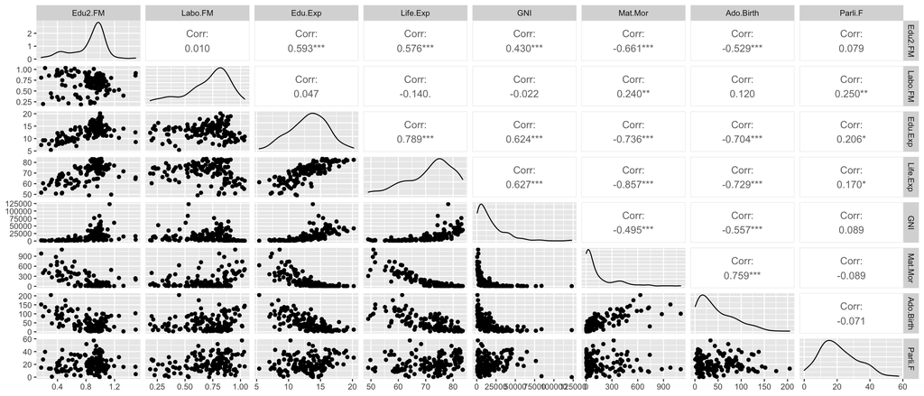

```r
library(ggplot2)
ggpairs(data)
```

Some of the distributions are really skewed towards the low values. Like GNI and Mat.Mor and Ado.Birth. Life.Exp is skewed towards the right side, meaning that most of the countries have decently high life expetation. There are also some clear trends in the data like Life.Exp and Mat.Mor, which is logical: lower life expectancy also correlates with mother mortality.

Lets then move on to computing the PCA. First on non-standardized data set.

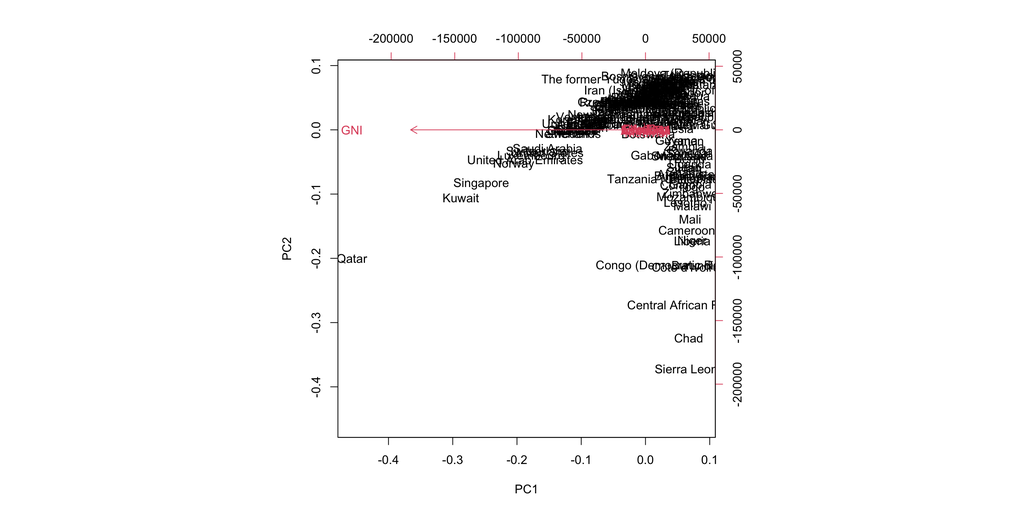

```r
pcafit = prcomp(data)
biplot(pcafit)
```

The plot shows that GNI has vastly greater magnitude than other variables.

Lets then normalize the data and repeat

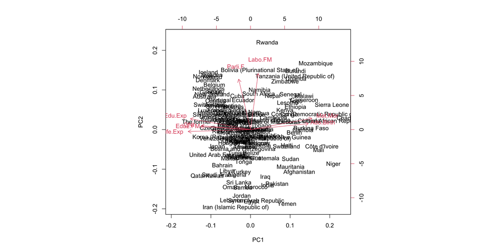

```r
data_norm = scale(data)
pcafit = prcomp(data_norm)
biplot(pcafit)
```

In the countries most of the variation is from the Edu.exp, Edu.Pm, GNI, Life.exp vs. Mat.mor and Ado.Birth. Then the second highest variation (second component) combines the Parli.F and Labo.FM.

Then next we look at the tea data set.

```r
#install.packages("FactoMineR")
library(FactoMineR)
data(tea)
dim(tea)
```

```
## [1] 300  36
```

```r
str(tea)
```

```
## 'data.frame':    300 obs. of  36 variables:
##  $ breakfast       : Factor w/ 2 levels "breakfast","Not.breakfast": 1 1 2 2 1 2 1 2 1 1 ...
##  $ tea.time        : Factor w/ 2 levels "Not.tea time",..: 1 1 2 1 1 1 2 2 2 1 ...
##  $ evening         : Factor w/ 2 levels "evening","Not.evening": 2 2 1 2 1 2 2 1 2 1 ...
##  $ lunch           : Factor w/ 2 levels "lunch","Not.lunch": 2 2 2 2 2 2 2 2 2 2 ...
##  $ dinner          : Factor w/ 2 levels "dinner","Not.dinner": 2 2 1 1 2 1 2 2 2 2 ...
##  $ always          : Factor w/ 2 levels "always","Not.always": 2 2 2 2 1 2 2 2 2 2 ...
##  $ home            : Factor w/ 2 levels "home","Not.home": 1 1 1 1 1 1 1 1 1 1 ...
##  $ work            : Factor w/ 2 levels "Not.work","work": 1 1 2 1 1 1 1 1 1 1 ...
##  $ tearoom         : Factor w/ 2 levels "Not.tearoom",..: 1 1 1 1 1 1 1 1 1 2 ...
##  $ friends         : Factor w/ 2 levels "friends","Not.friends": 2 2 1 2 2 2 1 2 2 2 ...
##  $ resto           : Factor w/ 2 levels "Not.resto","resto": 1 1 2 1 1 1 1 1 1 1 ...
##  $ pub             : Factor w/ 2 levels "Not.pub","pub": 1 1 1 1 1 1 1 1 1 1 ...
##  $ Tea             : Factor w/ 3 levels "black","Earl Grey",..: 1 1 2 2 2 2 2 1 2 1 ...
##  $ How             : Factor w/ 4 levels "alone","lemon",..: 1 3 1 1 1 1 1 3 3 1 ...
```

[output cut: 22 more lines]

```r
library(dplyr)
library(tidyr)
keep_columns <- c("Tea", "How", "how", "sugar", "where", "lunch")
tea_time <- select(tea, keep_columns)
```

```
## Note: Using an external vector in selections is ambiguous.
## ℹ Use `all_of(keep_columns)` instead of `keep_columns` to silence this message.
## ℹ See <https://tidyselect.r-lib.org/reference/faq-external-vector.html>.
```

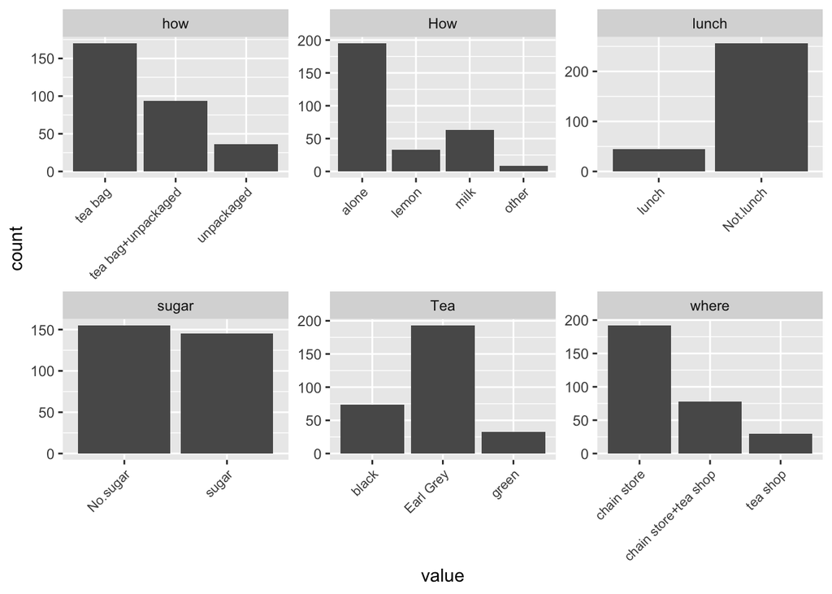

```r
gather(tea_time) %>% ggplot(aes(value)) + facet_wrap("key", scales = "free") + geom_bar() + theme(axis.text.x = element_text(angle = 45, hjust = 1, size = 8))
```

Then time for MCA.

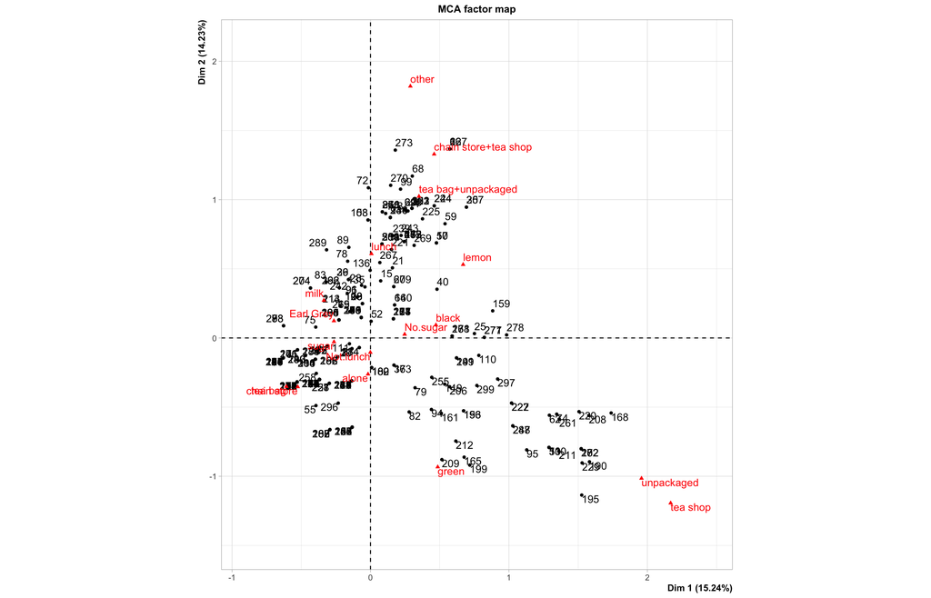

```r
mcafit = MCA(tea_time, graph=FALSE)
plot(mcafit)
```

MCA is the PCA equivalent for factored data. Because it is not really meaningful to calculate variance of a factor (at least in the standard way, we need to do some special treatment, that is, MCA).